# ST661 Assignment1

Paul Williamson, 18145469

12/10/2018

# Question 1

**(a) Construct a vector with values 10,11,12,13,14.** *Do this using :, c and seq. Assign your result to x.*

```r
x1 <- (10:14)
x1
```

```
## [1] 10 11 12 13 14
```

```r
x2 <- c(10,11,12,13,14)
x2
```

```
## [1] 10 11 12 13 14
```

```r
x3 <- seq(10, 14)
x3
```

```
## [1] 10 11 12 13 14
```

**(b) Construct a vector with values 14,10,11,13,12. Call it y.**

```r
y <- c(14,10,11,13,12)
y
```

```
## [1] 14 10 11 13 12
```

**(c) Extract the third value of x.**

```r
x1[3]
```

```
## [1] 12
```

**(d) Extract the second and fourth values of y.**

```r
y[2]; y[4]
```

```
## [1] 10
```

```
## [1] 13
```

**(e) Write a sentence explaining what the next line of code does.**

```r
result <- sum(x1>y)
result
```

```
## [1] 3
```

```r
message("This function makes an element-wise comparison of the elements in vector x\nwith the elements in vector y and count those elements in vector x which are larger than\ntheir positional counterpart in vector y; In this case the result is 3.")
```

```
## This function makes an element-wise comparison of the elements in vector x
## with the elements in vector y and count those elements in vector x which are larger than
## their positional counterpart in vector y; In this case the result is 3.
```

**(f) Write a sentence explaining what the next line of code does. (Look up the help page for abs.)**

```r
result <- sum(abs(x2-y) == 1)
result
```

```
## [1] 2
```

```r
message("The (x-y) returns a 'difference' vector with values equal to the element-wise difference between vector x values and vector y values;
the abs() returns a vector with the absolute (positive) magnitude of the values in that 'difference' vector;
the '== 1' returns a 'logical' vector with values true for those values equal to 1 and false for any other value not equal to 1;
the sum function results in a summation of all the elements in the resulting 'logical' vector, it treats a false value as 0 and a true value as 1;
the overall effect or result is a count of the number of elements in vector x which are of magnitude 1 away from their positional counterpart in vector y.")
```

```
## The (x-y) returns a 'difference' vector with values equal to the element-wise difference between vector x values and vector y values;
## the abs() returns a vector with the absolute (positive) magnitude of the values in that 'difference' vector;
## the '== 1' returns a 'logical' vector with values true for those values equal to 1 and false for any other value not equal to 1;
## the sum function results in a summation of all the elements in the resulting 'logical' vector, it treats a false value as 0 and a true value as 1;
## the overall effect or result is a count of the number of elements in vector x which are of magnitude 1 away from their positional counterpart in vector y.
```

**(g) Write code which implements the following formula. summation[i=1:5]Xi^2/Yi**

```r
x <- 1:5
y <- x
result <- sum((x*x)/y)
result
```

```
## [1] 15
```

**(h) Form a 5 x 2 matrix using the values in x and y.**

```r
new_matrix <- cbind(x3,y)
new_matrix
```

```
##      x3 y
## [1,] 10 1
## [2,] 11 2
## [3,] 12 3
## [4,] 13 4
## [5,] 14 5
```

# Question 2

```r
house <- read.csv("C:/Users/PAUL/Documents/.Maynooth HDip/ST661 R programming/Assignment1/house.csv",row.names=1)
head(house)
```

```
##             TooDark  Damp NoBathShower NoIndoorToilet
## Netherlands   0.037 0.142        0.000          0.000
## Spain         0.069 0.176        0.000          0.000
## Norway        0.041 0.082        0.001          0.001
## Switzerland   0.058 0.086        0.001          0.001
## Iceland       0.018 0.174        0.001          0.003
## Malta         0.067 0.100        0.002          0.000
```

**(a) Use head to check the first few rows of the data.**

```r
head(house)
```

```
##             TooDark  Damp NoBathShower NoIndoorToilet
## Netherlands   0.037 0.142        0.000          0.000
## Spain         0.069 0.176        0.000          0.000
## Norway        0.041 0.082        0.001          0.001
## Switzerland   0.058 0.086        0.001          0.001
## Iceland       0.018 0.174        0.001          0.003
## Malta         0.067 0.100        0.002          0.000
```

**(b) Extract the row of the data for Ireland.**

```r
house["Ireland",]
```

```
##         TooDark  Damp NoBathShower NoIndoorToilet
## Ireland   0.056 0.132        0.006          0.003
```

**(c) Find Spain’s value for TooDark.**

```r
house["Spain",1]
```

```
## [1] 0.069
```

**(d) For how many countries is the percentage without an indoor toilet 0?**

```r
count_NoIndoorToilet <- sum(house[,4] == 0)
count_NoIndoorToilet
```

```
## [1] 5
```

**(e) For how many countries is the percentage without an indoor toilet and without a bath/shower both 0?**

```r
count_NoIndoorToilet_NoBathShower <- sum((house[,4] == 0) & (house[,3] == 0))
count_NoIndoorToilet_NoBathShower
```

```
## [1] 2
```

**(f) Find the names of the countries where the percentage without an indoor toilet and without a** **bar/shower are both zero. Your code should give a vector of the country names.**

```r
no_modCons <- subset(house, (house[,4] == 0) & (house[,3] == 0))
no_modCons <- rownames(no_modCons)
no_modCons
```

```
## [1] "Netherlands" "Spain"
```

**(g) Find the maximum value of the variable Damp.**

```r
max_damp <- max(house$Damp)
max_damp
```

```
## [1] 0.306
```

# Question 3

```r
load("C:/Users/PAUL/Documents/.Maynooth HDip/ST661 R programming/Assignment1/worldcup.Rdata")
head(gtimes) # display data
```

```
## [1]  67 132 147 258 320 355
```

```r
head(ngoals) # display data
```

```
## [1] 1 2 1 2 6 3
```

**(a) Draw a barplot of the number of goals per match. What is the most frequent number of goals?** **Find the mean and the median.**

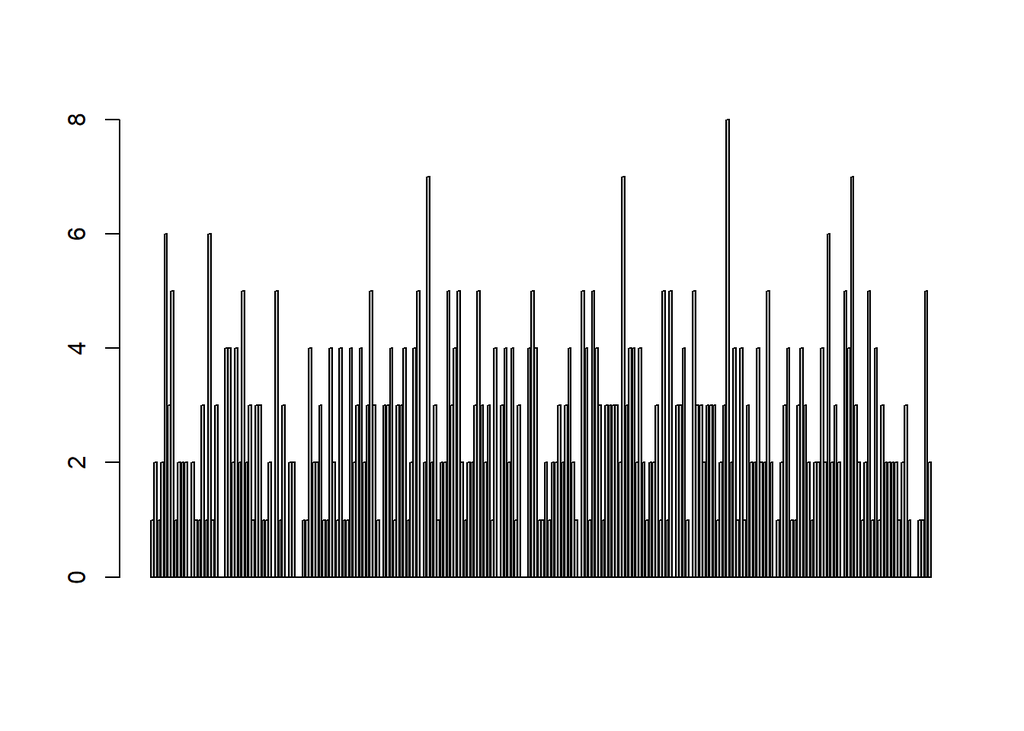

```r
barplot(ngoals) # plot
```

```r
mode_goals <- max(unique(ngoals))

mean_goals <- mean(ngoals)
mean_goals
```

```
## [1] 2.478448
```

```r
median_goals <- median(ngoals)
median_goals
```

```
## [1] 2
```

**(b) The first 52 matches were played in 1990, the next 52 matches were played in 1994, the next 64** **matches were played in 1998, and the last 64 matches were played in 2002. Therefore elements** **52, 104, 168 and 232 of ngoals give the numbers of matches scored in the four finals. Extract** **these elements of ngoals into a vector.**

```r
goalsScoredInFinals <- ngoals[c(52,104,168,232)]
goalsScoredInFinals
```

```
## [1] 1 0 3 2
```

**(c) Make a vector of length 232 containing the year each match was played. Call your vector year.** **(Hint: use rep.)**

```r
yr1990 <- 52
yr1994 <- 52
yr1998 <- 64
yr2002 <- 64
year <- c(rep(1990, yr1990),rep(1994, yr1994),rep(1998, yr1998),rep(2002, yr2002))
year
```

```
##   [1] 1990 1990 1990 1990 1990 1990 1990 1990 1990 1990 1990 1990 1990 1990
##  [15] 1990 1990 1990 1990 1990 1990 1990 1990 1990 1990 1990 1990 1990 1990
##  [29] 1990 1990 1990 1990 1990 1990 1990 1990 1990 1990 1990 1990 1990 1990
##  [43] 1990 1990 1990 1990 1990 1990 1990 1990 1990 1990 1994 1994 1994 1994
##  [57] 1994 1994 1994 1994 1994 1994 1994 1994 1994 1994 1994 1994 1994 1994
##  [71] 1994 1994 1994 1994 1994 1994 1994 1994 1994 1994 1994 1994 1994 1994
##  [85] 1994 1994 1994 1994 1994 1994 1994 1994 1994 1994 1994 1994 1994 1994
##  [99] 1994 1994 1994 1994 1994 1994 1998 1998 1998 1998 1998 1998 1998 1998
## [113] 1998 1998 1998 1998 1998 1998 1998 1998 1998 1998 1998 1998 1998 1998
## [127] 1998 1998 1998 1998 1998 1998 1998 1998 1998 1998 1998 1998 1998 1998
## [141] 1998 1998 1998 1998 1998 1998 1998 1998 1998 1998 1998 1998 1998 1998
## [155] 1998 1998 1998 1998 1998 1998 1998 1998 1998 1998 1998 1998 1998 1998
## [169] 2002 2002 2002 2002 2002 2002 2002 2002 2002 2002 2002 2002 2002 2002
## [183] 2002 2002 2002 2002 2002 2002 2002 2002 2002 2002 2002 2002 2002 2002
## [197] 2002 2002 2002 2002 2002 2002 2002 2002 2002 2002 2002 2002 2002 2002
## [211] 2002 2002 2002 2002 2002 2002 2002 2002 2002 2002 2002 2002 2002 2002
## [225] 2002 2002 2002 2002 2002 2002 2002 2002
```

**(d) Turn the vector year into a factor. Make a data frame where the first variable is ngoals and** **the second is year.**

```r
year <- factor(year)
year
```

```
##   [1] 1990 1990 1990 1990 1990 1990 1990 1990 1990 1990 1990 1990 1990 1990
##  [15] 1990 1990 1990 1990 1990 1990 1990 1990 1990 1990 1990 1990 1990 1990
##  [29] 1990 1990 1990 1990 1990 1990 1990 1990 1990 1990 1990 1990 1990 1990
##  [43] 1990 1990 1990 1990 1990 1990 1990 1990 1990 1990 1994 1994 1994 1994
##  [57] 1994 1994 1994 1994 1994 1994 1994 1994 1994 1994 1994 1994 1994 1994
##  [71] 1994 1994 1994 1994 1994 1994 1994 1994 1994 1994 1994 1994 1994 1994
##  [85] 1994 1994 1994 1994 1994 1994 1994 1994 1994 1994 1994 1994 1994 1994
##  [99] 1994 1994 1994 1994 1994 1994 1998 1998 1998 1998 1998 1998 1998 1998
## [113] 1998 1998 1998 1998 1998 1998 1998 1998 1998 1998 1998 1998 1998 1998
## [127] 1998 1998 1998 1998 1998 1998 1998 1998 1998 1998 1998 1998 1998 1998
## [141] 1998 1998 1998 1998 1998 1998 1998 1998 1998 1998 1998 1998 1998 1998
## [155] 1998 1998 1998 1998 1998 1998 1998 1998 1998 1998 1998 1998 1998 1998
## [169] 2002 2002 2002 2002 2002 2002 2002 2002 2002 2002 2002 2002 2002 2002
## [183] 2002 2002 2002 2002 2002 2002 2002 2002 2002 2002 2002 2002 2002 2002
## [197] 2002 2002 2002 2002 2002 2002 2002 2002 2002 2002 2002 2002 2002 2002
## [211] 2002 2002 2002 2002 2002 2002 2002 2002 2002 2002 2002 2002 2002 2002
## [225] 2002 2002 2002 2002 2002 2002 2002 2002
## Levels: 1990 1994 1998 2002
```

```r
year_goals_df <- data.frame(ngoals,year)
year_goals_df
```

```
##     ngoals year
## 1        1 1990
## 2        2 1990
## 3        1 1990
## 4        2 1990
## 5        6 1990
## 6        3 1990
## 7        5 1990
## 8        1 1990
## 9        2 1990
## 10       2 1990
## 11       2 1990
## 12       0 1990
## 13       2 1990
## 14       1 1990
```

[output cut: 218 more lines]

**(e) Make a vector called matchn containing the number of the match for that world cup. The** **vector should be 1..52, 1..52, 1..64, 1..64. Add this vector to the data frame.**

```r
matchn <- c(seq(1,52),seq(1,52),seq(1,64),seq(1,64))
matchn
```

```
##   [1]  1  2  3  4  5  6  7  8  9 10 11 12 13 14 15 16 17 18 19 20 21 22 23
##  [24] 24 25 26 27 28 29 30 31 32 33 34 35 36 37 38 39 40 41 42 43 44 45 46
##  [47] 47 48 49 50 51 52  1  2  3  4  5  6  7  8  9 10 11 12 13 14 15 16 17
##  [70] 18 19 20 21 22 23 24 25 26 27 28 29 30 31 32 33 34 35 36 37 38 39 40
##  [93] 41 42 43 44 45 46 47 48 49 50 51 52  1  2  3  4  5  6  7  8  9 10 11
## [116] 12 13 14 15 16 17 18 19 20 21 22 23 24 25 26 27 28 29 30 31 32 33 34
## [139] 35 36 37 38 39 40 41 42 43 44 45 46 47 48 49 50 51 52 53 54 55 56 57
## [162] 58 59 60 61 62 63 64  1  2  3  4  5  6  7  8  9 10 11 12 13 14 15 16
## [185] 17 18 19 20 21 22 23 24 25 26 27 28 29 30 31 32 33 34 35 36 37 38 39
## [208] 40 41 42 43 44 45 46 47 48 49 50 51 52 53 54 55 56 57 58 59 60 61 62
## [231] 63 64
```

```r
year_goals_df <- cbind(year_goals_df,matchn)
year_goals_df
```

```
##     ngoals year matchn
## 1        1 1990      1
## 2        2 1990      2
## 3        1 1990      3
## 4        2 1990      4
## 5        6 1990      5
## 6        3 1990      6
## 7        5 1990      7
## 8        1 1990      8
## 9        2 1990      9
## 10       2 1990     10
## 11       2 1990     11
## 12       0 1990     12
## 13       2 1990     13
## 14       1 1990     14
```

[output cut: 218 more lines]

**(f) Extract the rows 52, 104, 168 and 232 of the data frame. Which year’s final has the most goals?**

```r
max_FinalsGoals <- max(year_goals_df[c(52,104,168,232),1])
max_FinalsGoals
```

```
## [1] 3
```

**(g) Make a boxplot of the number of goals played for each year. What can you say about the 8 goal match?**

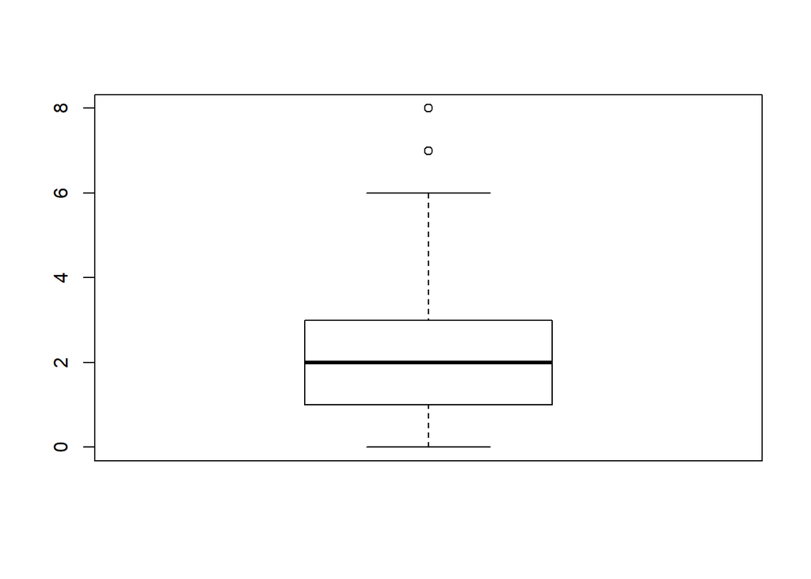

```r
boxplot(year_goals_df$ngoals)
```

```r
message("What can you say about the 8 goal match? It would seem to be an outlier.")
```

```
## What can you say about the 8 goal match? It would seem to be an outlier.
```

**(h) (Advanced, optional). The vector gtimes contains the cumulative time in minutes from the** **start of the 1990 world cup in which goals were scored (counting playing time only.) Construct** **another vector minute containing the minute of each game in which the goal is scored. In what** **minutes of the matches are goals most likely to occur?**

```r
head(gtimes)
```

```
## [1]  67 132 147 258 320 355
```

```r
minute <- vector()
currTime <- 1

for (currTime in 1:length(gtimes))
  {
    currentTime <- gtimes[currTime]
    while(currentTime>90)
    {
      currentTime <- currentTime-90
    }
    minute[currTime] <- currentTime
  }
minute
```

```
##   [1] 67 42 57 78 50 85 25 39 50 61 78 90 40 63 79 28 39 55 65 71 49  8 73
##  [24] 53 64 58 83 27 79 75 11 76 86 88 30 35 36 46 47 59 75 33 10 80 86 16
##  [47] 22 48 74 22 42 61 81 63 68 20 29 55 63 89 90  5  9 22 46 90  9 78 52
##  [70] 65 85 82 32 75 88 20 28 38 90 64 10 71 12 54 63 75 82 80 51 82 89 65
##  [93] 85 78 83 38 25 25 61 65 83 17 67 60 80 71 81 86 85 61 51 55 85 90 39
## [116] 44 11 15 34 43 89 11 84  8 31 47 75 26 52 18 50 86  2 44 60 89 14 48
## [139] 21 43 55 16 35 52 65 72 35 52 90 69 42 65 84 39 66 73  4 37 59 81 65
## [162]  7 26 45  8 21 28  5 55 65 90 18 44 90 19 66 67 70 12 20 37 52 63 48
## [185] 57 15 41 44 46 72 75 81 23 46 43 47 77  5 45 90 61 90  6  8 11 40 90
## [208] 15 74 86  6 51 85 88 11 16 18 58 75 11 41 72 25 88  6 18 25 58 87 53
## [231] 63 64 76 81 47 75 78 78 88 20 25 44 80  8 30 37 40  4 38 73 38 45 59
## [254] 60 78 90 10 45 49 85 68 34 77 90 28 51 74 84 21 25 47 73 78 27 45 53
## [277] 69 72 28  8 64 45 43 89 46 66  9 45 50 70 90  7 75 89 36 68 77 85 13
## [300] 52 26 38 42 71 80 83 43 47 55 62 77 31 55 72 80 83  2 54 73 80 40 84
## [323] 87 83 47 79 90 49 89 90 22 46 85 78 83 88 20 55  6 19 55 58 81 88 90
## [346] 12 42 56  1 11 59 86 19 45 74 90  7 71  4 18 75 90 50 57  4 10 72 20
## [369] 29 39 54 74 36 11 27 45 68 70 18  3 12 60 76 78 47 75 86 38 48 90  6
## [392] 10 16 45 45  2 11 27 50 60 48 80 85 12 17 89 46 87 46 47 69 13 21 35
## [415] 27 45 90 30 39 52 45 47 83 20 25 40 45 70 73 84 90 24 59 39 55 63 90
## [438] 63 44 74 82 87 60 45 50 87  7 27 61 65 57 59 67 75 26 53 59 64  4 29
## [461] 36 39 71 19 90 66 16 52 27 35 63 10 53 69 83 44  4 55 73 76 15 32 45
## [484] 55  5 28 57 56 86 51 24 78 13 17 14 65 77 88 22 67 20 26 38 46 69 88
## [507] 50 79  7 61 87 59 88  4 31 45 53 56 45 65 73 84 10 13 38 39 56 62 64
## [530]  6  9 85 34 85 48 48 75  7 52 78 82 88 70  3  5 66 83 88  5 22 44 11
## [553] 37  8 90  8 65 67 87 12 18 88 23 45 50 39 75 49  1  9 13 32 90 67 79
```

```r
minute <- factor(minute)
table(minute)
```

```
## minute
##  1  2  3  4  5  6  7  8  9 10 11 12 13 14 15 16 17 18 19 20 21 22 23 24 25
##  2  3  2  7  6  6  6  8  5  7 10  6  5  2  4  5  3  7  4  8  4  6  2  2  8
## 26 27 28 29 30 31 32 33 34 35 36 37 38 39 40 41 42 43 44 45 46 47 48 49 50
##  5  7  6  3  3  3  3  1  3  5  4  4  8 10  5  2  5  5  8 19  9 10  7  4  9
## 51 52 53 54 55 56 57 58 59 60 61 62 63 64 65 66 67 68 69 70 71 72 73 74 75
##  5  9  6  3 12  4  5  4  8  6  7  2  9  6 12  5  7  4  5  5  6  6  8  6 14
## 76 77 78 79 80 81 82 83 84 85 86 87 88 89 90
##  4  5 12  5  8  6  5 10  6 12  8  7 13  8 26
```

```r
names(which.max(table(minute)))
```

```
## [1] "90"
```